# StudentNoteBook

Student

10/8/2019

## Before you start

Make sure that you have copied the StudentNoteBook to your Exam_HandIn folder, as well as your 2 .CSV files. Test this by running the following chunk

```r
getwd()
```

```
## [1] "C:/Users/Valio/Desktop/Exam_HandIn"
```

Make sure it returns your Exam_HandIn folder. If it does not return, save your StudentNoteBook in the Exam_HandIn folder. If you know that you are saving in the Exam_HandIn folder you can continue.

Now add your name:

Name: Valentin Vasilev

Studentnumber: 3860140

Class: PC05

## Introduction text

In this exam we will go over some of the assignments you made earlier. Based on the “introduction to the tidyverse”, the “working with data in the tidyverse”, and the “data visualisation with ggplot2” courses. In three sections we will focus on some of the questions and theory presented in these courses, you might actually recognize the dataset and some of the questions.

Starting with a recap of the introduction of the Tidyverse we will look at some exercises of the Gapminder we worked with. As we will be using different libraries you need to enable these:

```r
library(gapminder)
library(ggplot2)
library(tidyverse)
library(dplyr)
library(readr)
```

Let’s refresh our minds by looking at the gapminder dataset.

```r
#View(gapminder)
# Use the View function if you want to see the whole table for yourself. This will have no effect on your final output.
view(gapminder)
#head(gapminder)
#the header code is only for our purposes to make it easier to work with the data set. someone reading the final document will understand the dataset you have been working with.
```

## Exam questions

### Part 1

Let’s try for the first assignment something straight forward:

1. Which 2 filters would you need to get below mentioned table?

```r
gapminder %>% filter(country == "China", year == "2002")
```

```
## # A tibble: 1 x 6
##   country continent  year lifeExp        pop gdpPercap
##   <fct>   <fct>     <int>   <dbl>      <int>     <dbl>
## 1 China   Asia       2002    72.0 1280400000     3119.
```

2. After filter we learned about arrange for the Gapminder. If we want to complete this code to have the filter for 1957 and the dataset arranged descending for population.

```r
# Filter for the year 1957,
#  then arrange in descending order of population

gapminder %>%
filter( year == "1957" ) %>%
arrange(desc(pop))
```

```
## # A tibble: 142 x 6
##    country        continent  year lifeExp       pop gdpPercap
##    <fct>          <fct>     <int>   <dbl>     <int>     <dbl>
##  1 China          Asia       1957    50.5 637408000      576.
##  2 India          Asia       1957    40.2 409000000      590.
##  3 United States  Americas   1957    69.5 171984000    14847.
##  4 Japan          Asia       1957    65.5  91563009     4318.
##  5 Indonesia      Asia       1957    39.9  90124000      859.
##  6 Germany        Europe     1957    69.1  71019069    10188.
##  7 Brazil         Americas   1957    53.3  65551171     2487.
##  8 United Kingdom Europe     1957    70.4  51430000    11283.
##  9 Bangladesh     Asia       1957    39.3  51365468      662.
## 10 Italy          Europe     1957    67.8  49182000     6249.
## # ... with 132 more rows
```

3. finally we can combine this with a mutate, In this exercise, you’ll combine all three of the verbs you’ve learned in this chapter, to find the countries from high to low “life expectancy in months”, for the year 2002. Complete the code below:

```r
# Filter for the year 2002
# mutate the life expextency to represent months instead of years
# and arrange the gapminder dataset with life expectancy in months from high to low

gapminder %>%
filter(year == "2002") %>%
mutate(lifeExpMonths = 12 * lifeExp ) %>%
arrange( desc(lifeExpMonths) )
```

```
## # A tibble: 142 x 7
##    country         continent  year lifeExp      pop gdpPercap lifeExpMonths
##    <fct>           <fct>     <int>   <dbl>    <int>     <dbl>         <dbl>
##  1 Japan           Asia       2002    82     1.27e8    28605.          984
##  2 Hong Kong, Chi~ Asia       2002    81.5   6.76e6    30209.          978.
##  3 Switzerland     Europe     2002    80.6   7.36e6    34481.          967.
##  4 Iceland         Europe     2002    80.5   2.88e5    31163.          966
##  5 Australia       Oceania    2002    80.4   1.95e7    30688.          964.
##  6 Italy           Europe     2002    80.2   5.79e7    27968.          963.
##  7 Sweden          Europe     2002    80.0   8.95e6    29342.          960.
##  8 Spain           Europe     2002    79.8   4.02e7    24835.          957.
##  9 Canada          Americas   2002    79.8   3.19e7    33329.          957.
## 10 Israel          Asia       2002    79.7   6.03e6    21906.          956.
## # ... with 132 more rows
```

Now that we have gained some heat in our coding we will pick up our pace. Firstly we want to look at the data in 1952, to filter for 1952 we use the following code:

4. Complete this code to get this image.

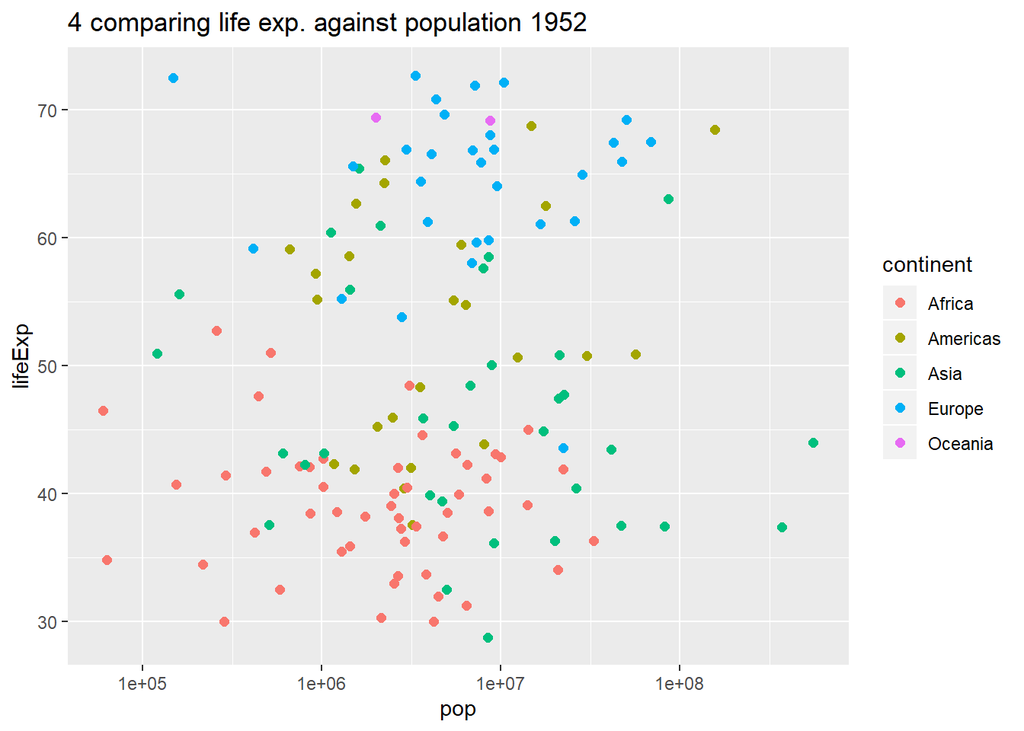

```r
gapminder_1952 <- gapminder %>%
  filter(year == "1952")

ggplot(gapminder_1952, aes(x= pop , y= lifeExp , colour= continent )) +
  geom_point(size = 2) +
  scale_x_log10() +
  ggtitle( '4 comparing life exp. against population 1952')
```

5. Complete the code to get this image

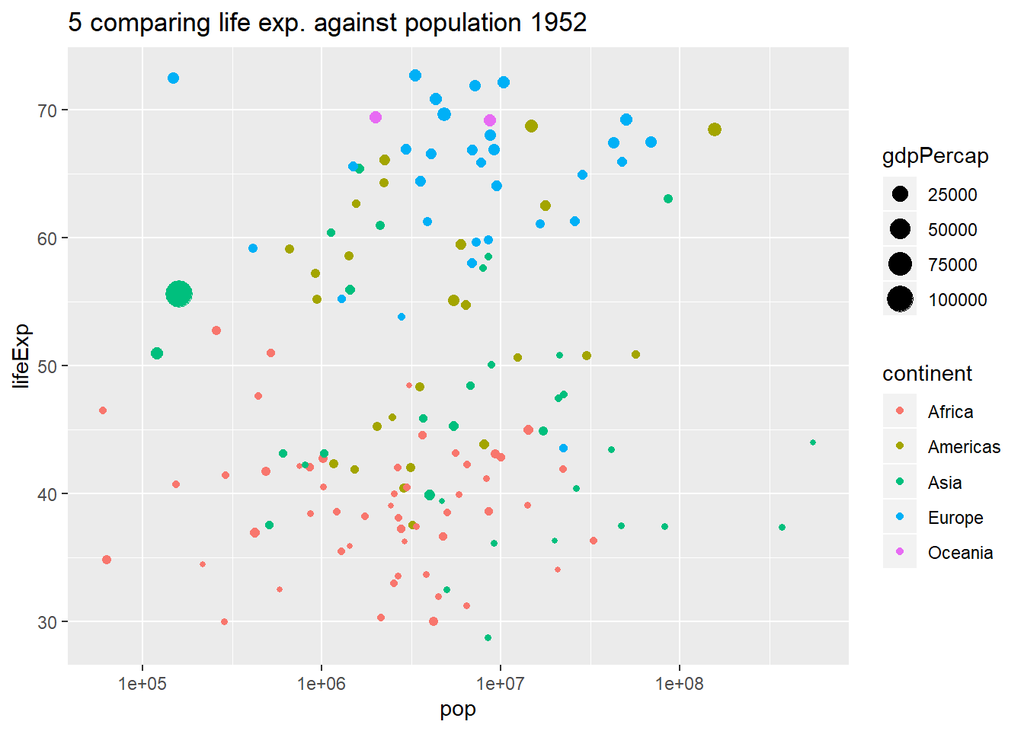

```r
gapminder_1952 <- gapminder %>%
  filter( year == "1952" )

ggplot(gapminder_1952, aes(x = pop, y = lifeExp , colour = continent , size = gdpPercap )) +
  geom_point() +
  scale_x_log10() +
  ggtitle( '5 comparing life exp. against population 1952')
```

6. Complete the code to get this image

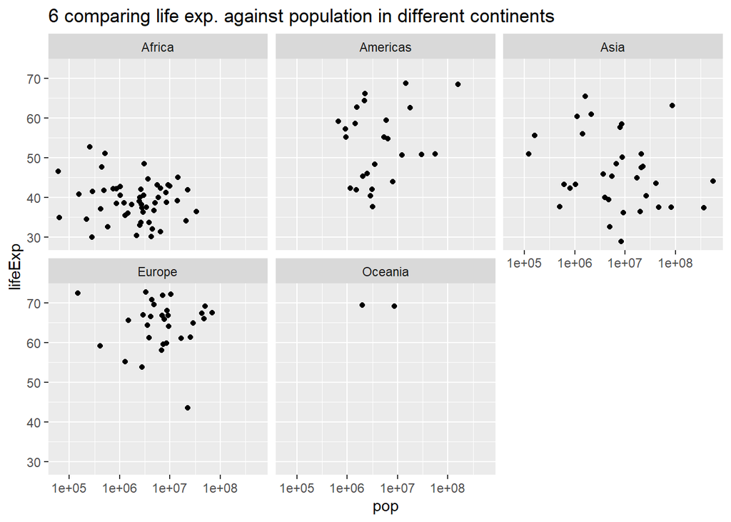

```r
gapminder_1952 <- gapminder %>%
  filter(year == "1952")

ggplot(gapminder_1952, aes(x= pop , y= lifeExp )) +
  geom_point() +
  scale_x_log10() +
  facet_wrap(~ continent ) +
  ggtitle(  '6 comparing life exp. against population in different continents')
```

7. combining the techniques from question 6 and 5 we can now make an overview of Gapminder for all years to create the image below, what is the code for this?

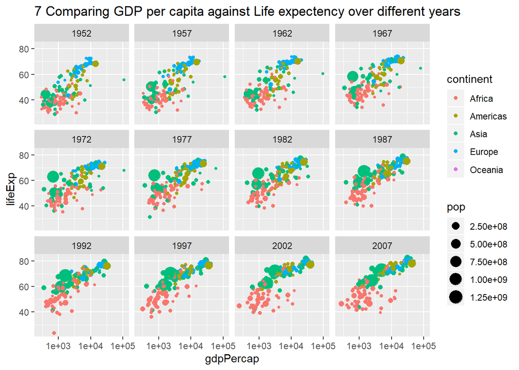

```r
ggplot(gapminder, aes(x= gdpPercap , y= lifeExp , colour= continent , size= pop )) +
  geom_point() +
  scale_x_log10() +
  facet_wrap(~  year ) +
  ggtitle( '7 Comparing GDP per capita against Life expectency over different years')
```

As you see, in the last assignments we have been working with the ggplot2 library, let’s dive deeper into this library.